# Representación de datos funcionales

## Instalación de librerías

```r
library(fda) # para trabajar con datos funcionales
library(caret) # para validación cruzada
```

# Introducción

En este notebook hablaremos de la transformación de datos discretos a funcionales. Tal como introdujimos en el video inicial, en FDA ya no hablamos de datos dicretos como unidad mínima de medida, sino de funciones. Sin embargo, buena parte de los relevamientos de datos, ya sea por limitaciones en los instrumentos de recolección u otras razones, se realizan en forma discreta. Por lo tanto, es necesario transformar estos datos a una representación funcional para poder aplicar las técnicas de FDA. Es en este punto donde entran en juego las bases funcionales.

## Bases funcionales

Las bases funcionales son conjuntos de funciones que se utilizan para representar datos funcionales. Son análogas a las variables independientes en la regresión lineal, donde cada función contribuye a la forma general de la función que se está ajustando a los datos.

$$\LARGE \hat{\mathbf{X}} = \sum_{j = 1}^{j} \hat{\alpha}_j \phi_j$$

### Fourier y B-splines

[figure not shown]

```r
# Bases bsplines
x <- seq(0,1,length.out=100)
bsbasis_obj <- create.bspline.basis(rangeval=c(0,1),
                                    nbasis=10, norder=3)
bsbasisevals <- eval.basis(x, bsbasis_obj)
matplot(x, bsbasisevals, type='l', lty=1, col=rainbow(15),
        xlab="x", ylab="basis fns",
        main="Bases B-spline con polinomios de grado 3")
```

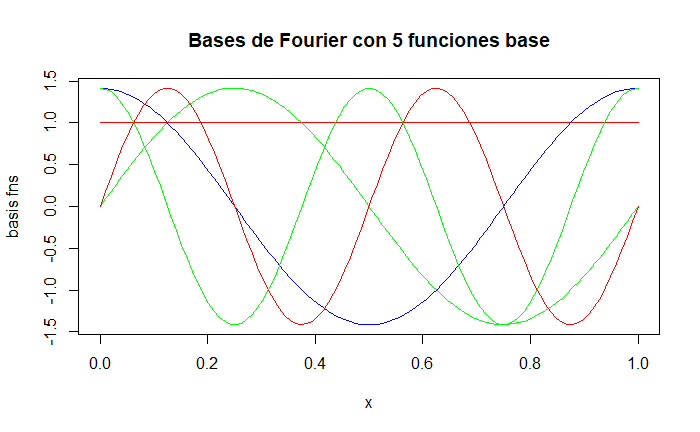

```r
# Bases de Fourier
fbasis_obj <- create.fourier.basis(rangeval=c(0,1),
                                   nbasis=5) # period = 1
fbasisevals <- eval.basis(x, fbasis_obj)
matplot(x, fbasisevals[, 1:5], type='l', lty=1, col=rainbow(3),
        xlab="x", ylab="basis fns",
        main="Bases de Fourier con 5 funciones base")
```

### Ejemplo

En el siguiente ejemplo, generaremos datos sintéticos que siguen una función sinusoidal.

```r
set.seed(42)
dias <- seq(0, 2 * pi, length.out = 365)  # Un año en eje X
y_real <- 10 + 5 * sin(dias) + 2 * cos(2 * dias)  # Componente "verdadera"
y_observada <- y_real + rnorm(length(dias), mean = 0, sd = 3)  # Agregamos ruido
```

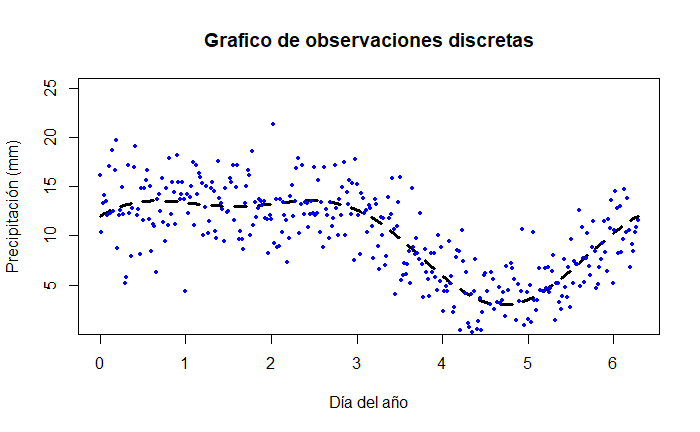

```r
plot(dias, y_real, type = "l", col = "black", lty = 2, xlab = "Día del año", lwd = 3,
       ylab = "Precipitación (mm)", main = paste("Grafico de observaciones discretas"),
       ylim = c(1, 25))
points(dias, y_observada, col = "blue", pch = 20, cex = 0.8)
```

Luego, ajustamos una curva a los datos observados. Para ello, utilizamos una base de funciones B-spline (pero también podríamos utilizar otras bases funcionales). Queremos observar cómo el incremento del número de funciones afecta al ajuste de la curva.

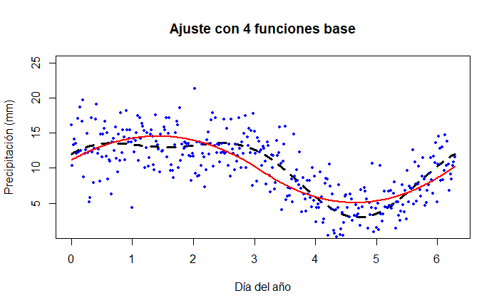

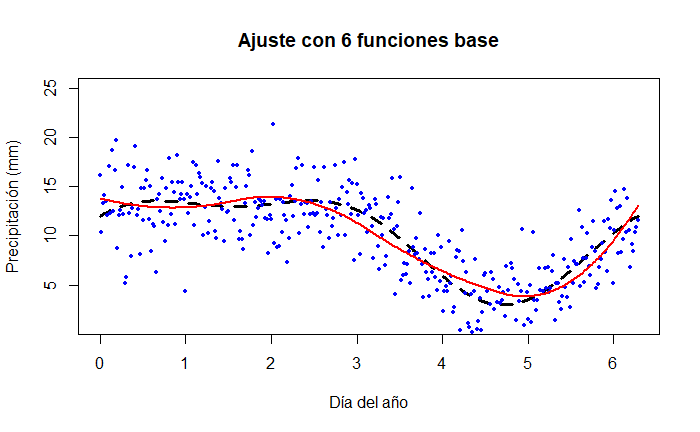

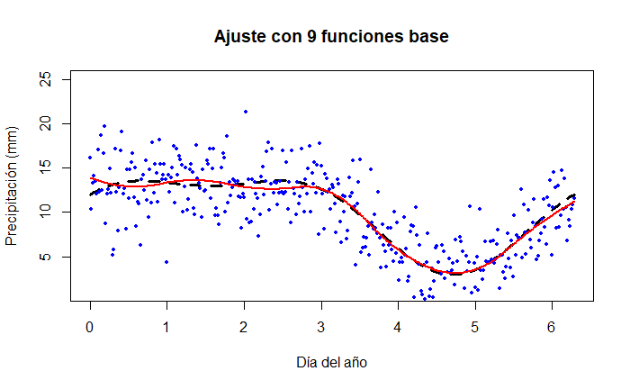

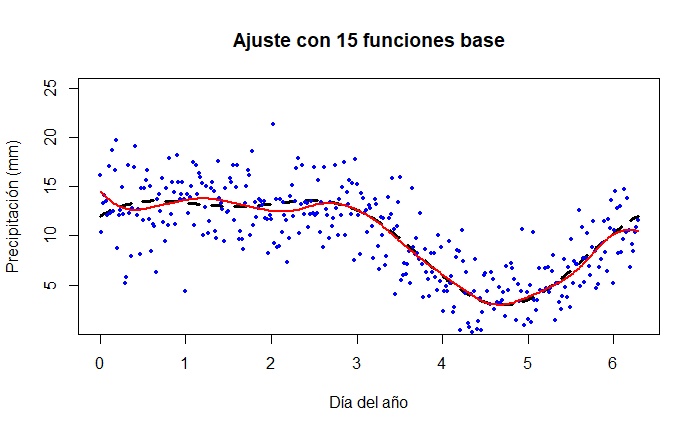

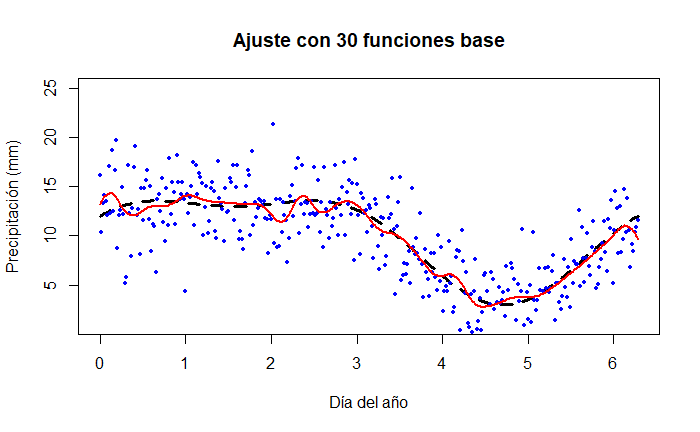

```r
crear_base_bspline <- function(x, nbasis, norder = 3) {
  if (nbasis < norder) {
    stop("nbasis debe ser al menos igual a norder.")
  }
  rango <- range(x)
  basis <- fda::create.bspline.basis(rangeval = rango, nbasis = nbasis, norder = norder)
  matriz_bspline <- eval.basis(x, basis)
  return(matriz_bspline)
}

# Definimos un vector caprichoso de nbasis
n_basis_options <- c(4, 6, 9, 15, 30)

for (nbasis in n_basis_options) {
  plot(dias, y_real, type = "l", col = "black", lty = 2, xlab = "Día del año", lwd = 3,
       ylab = "Precipitación (mm)", main = paste("Ajuste con", nbasis, "funciones base"),
       ylim = c(1, 25))
  points(dias, y_observada, col = "blue", pch = 20, cex = 0.8)

  X <- crear_base_bspline(dias, nbasis)
  coeficientes <- solve(t(X) %*% X) %*% t(X) %*% y_observada
  y_pred <- X %*% coeficientes

  lines(dias, y_pred, col = "red", lwd = 2, lty = 1)
}
```

### Cross-validation para nbasis

Si bien los gráficos permiten fácilmente visualizar cómo se ajusta la curva a los datos, es necesario contar con una métrica para evaluar cuál es el número óptimo de funciones base. En este caso, utilizaremos el error cuadrático medio (MSE) promedio obtenido a través de validación cruzada.

$$\LARGE \text{MSE} = \frac{1}{n} \sum_{i=1}^n \left( y_i - \hat{y}_i
\right)^2$$

```r
# Generamos un vector que almacenará los mse promedio
mse_promedio <- c()

for (nbasis in 4:30) {  #Trabajamos a partir de 4 nbasis
  fold_mse <- c()

  folds <- createFolds(dias, k = 5, list = TRUE, returnTrain = TRUE) #Trabajamos con cross-validation de 5 folds

  for (fold in folds) {
    train_idx <- fold
    test_idx <- setdiff(seq_along(dias), train_idx)

    X_train <- crear_base_bspline(dias[train_idx], nbasis)
    X_test <- crear_base_bspline(dias[test_idx], nbasis)
    y_train <- y_observada[train_idx]
    y_test <- y_observada[test_idx]

    coeficientes <- solve(t(X_train) %*% X_train) %*% t(X_train) %*% y_train
    y_pred <- X_test %*% coeficientes

    fold_mse <- c(fold_mse, mean((y_test - y_pred)^2))
  }

  mse_promedio <- c(mse_promedio, mean(fold_mse))
}
```

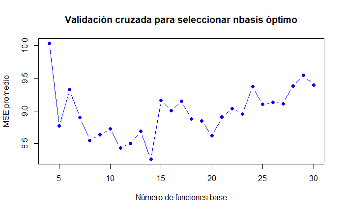

```r
# Graficamos la evolución de MSE
plot(4:30, mse_promedio, type = "b", pch = 16, col = "blue",
     xlab = "Número de funciones base", ylab = "MSE promedio",
     main = "Validación cruzada para seleccionar nbasis óptimo")
```

```r
nbasis_optimo <- which.min(mse_promedio) + 3  # Sumar 3 porque empieza en 4
cat("Número óptimo de funciones base:", nbasis_optimo, "\n")
```

```
Número óptimo de funciones base: 14
```